# STAT380 Final Project

Adam Abdel-Latif & Yuerong Shu

2026-04-27

## Task 1

### Relevant Info

Prior to each online match, players in the game lobby are presented with two options for the battlefield of the upcoming game (`Map1` and`Map2`). The players have the option to vote, and the resulting vote is recorded in the `MapVote` column. The winning map is listed in the `Choice` column. In the event of a tie vote, the map listed in `Map1` is chosen. (Games for which the player entered the lobby after the vote has taken place have no information in `Map1` and `Map2` but have the winning map presented in `Choice`.)

**Research Question:** Which maps are the most likely to win the map vote when they are an option?

**Strategy:** Find the rate for which each map is selected, both in total and when it is in the map pool. Ignore maps that are the “choice” when a player has entered the lobby after the vote has taken place. Find if there are any significant tie correlations between maps.

```r
library(dplyr)
library(tidyr)
library(ggplot2)

p1 <- read.csv("CODGames_p1_380.csv", stringsAsFactors = FALSE)
p2 <- read.csv("CODGames_p2_380.csv", stringsAsFactors = FALSE)

cod <- bind_rows(p1, p2)
```

```r
# fix misspellings and inconsistent capitalisation in map name columns
fix_map_name <- function(x) {
  x <- trimws(x)
  case_when(
    x == "Drive-in"                           ~ "Drive-In",
    x %in% c("Apocolypse", "APocalypse")      ~ "Apocalypse",
    x %in% c("Collateral", "Collaterel Strike",
              "Collaterol Strike",
              "Collateral Striek")             ~ "Collateral Strike",
    x %in% c("Miami", "Miami Sstrike")        ~ "Miami Strike",
    x %in% c("Deisel", "Diesel")              ~ "Diesel",
    x == "Riad"                               ~ "Raid",
    x == "Ruah"                               ~ "Rush",
    x == "yamantau"                           ~ "Yamantau",
    x == "Deprogam"                           ~ "Deprogram",
    x == "Amrada Strike"                      ~ "Armada Strike",
    TRUE                                      ~ x
  )
}

cod <- cod %>%
  mutate(
    Choice = fix_map_name(Choice),
    Map1   = fix_map_name(Map1),
    Map2   = fix_map_name(Map2)
  )
```

```r
# remove games where player joined after the vote (Map1 and Map2 are blank)
voted_games <- cod %>%
  filter(Map1 != "" & Map2 != "")
```

The table below shows how often each map was selected as the winning map across all games in the dataset, including matches where the player joined after the vote had already taken place.

```r
# overall rate: how often each map was chosen out of all games
total_games <- nrow(cod)

overall_rate <- cod %>%
  count(Choice, name = "total_wins") %>%
  mutate(overall_rate = round(total_wins / total_games, 3)) %>%
  arrange(desc(overall_rate))

overall_rate
```

```
##                    Choice total_wins overall_rate
## 1       Crossroads Strike         54        0.064
## 2                  Diesel         49        0.058
## 3                Standoff         47        0.056
## 4                 Express         44        0.052
## 5       Collateral Strike         40        0.048
## 6                Yamantau         39        0.046
## 7                    Raid         38        0.045
## 8               Checkmate         37        0.044
## 9            Nuketown '84         35        0.042
## 10              The Pines         35        0.042
## 11               Hijacked         34        0.041
## 12           Miami Strike         33        0.039
## 13                  Slums         33        0.039
## 14                 Moscow         32        0.038
## 15                   Rush         32        0.038
## 16             Apocalypse         30        0.036
## 17               Drive-In         30        0.036
## 18                    Zoo         29        0.035
## 19                 Cartel         27        0.032
## 20               Garrison         27        0.032
## 21              Satellite         23        0.027
## 22          Armada Strike         20        0.024
## 23                Amerika         19        0.023
## 24              Deprogram         17        0.020
## 25                Echelon         16        0.019
## 26                    WMD          7        0.008
## 27                 Jungle          5        0.006
## 28 Nuketown '84 Halloween          5        0.006
## 29                                 2        0.002
```

```r
# candidate rate: how often each map won when it was actually an option
candidates <- voted_games %>%
  pivot_longer(cols = c(Map1, Map2), names_to = "position", values_to = "map") %>%
  group_by(map) %>%
  summarise(
    times_candidate = n(),
    times_won = sum(map == Choice)
  ) %>%
  mutate(win_rate = round(times_won / times_candidate, 3))

# count wins that came from actual votes (strictly more votes, not ties)
vote_win_counts <- voted_games %>%
  filter(grepl("^[0-9]+ to [0-9]+$", MapVote)) %>%
  separate(MapVote, into = c("map1_votes", "map2_votes"), sep = " to ", convert = TRUE) %>%
  pivot_longer(cols = c(Map1, Map2), names_to = "position", values_to = "map") %>%
  mutate(
    my_votes = ifelse(position == "Map1", map1_votes, map2_votes),
    opp_votes = ifelse(position == "Map1", map2_votes, map1_votes),
    vote_win = (map == Choice) & (my_votes > opp_votes)
  ) %>%
  group_by(map) %>%
  summarise(vote_wins = sum(vote_win))

# join and compute both rates
candidates <- candidates %>%
  left_join(vote_win_counts, by = "map") %>%
  mutate(
    vote_wins = replace_na(vote_wins, 0),
    vote_win_rate = round(vote_wins / times_candidate, 3)
  ) %>%
  arrange(desc(win_rate))

candidates
```

```
## # A tibble: 29 × 6
##    map                times_candidate times_won win_rate vote_wins vote_win_rate
##    <chr>                        <int>     <int>    <dbl>     <int>         <dbl>
##  1 Nuketown '84 Hall…               1         1    1             0         0
##  2 Nuketown '84                    39        32    0.821        11         0.282
##  3 Crossroads Strike               58        45    0.776        14         0.241
##  4 Raid                            44        33    0.75         15         0.341
##  5 Diesel                          55        39    0.709        20         0.364
##  6 Standoff                        47        33    0.702        14         0.298
##  7 Slums                           41        27    0.659        12         0.293
##  8 Express                         62        39    0.629        17         0.274
##  9 Checkmate                       55        34    0.618        18         0.327
## 10 Collateral Strike               58        34    0.586        11         0.19
## # ℹ 19 more rows
```

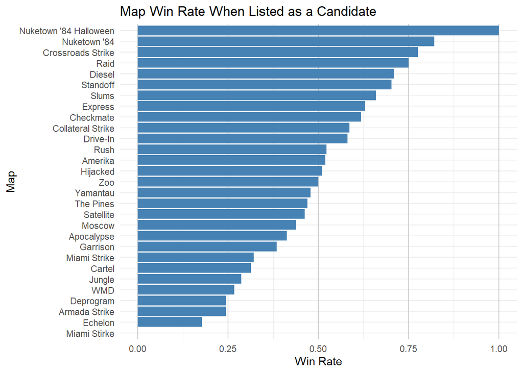

```r
ggplot(candidates, aes(x = reorder(map, win_rate), y = win_rate)) +
  geom_col(fill = "steelblue") +
  coord_flip() +
  labs(title = "Map Win Rate When Listed as a Candidate",
       x = "Map", y = "Win Rate") +
  theme_minimal() +
  theme(
    panel.grid.major.x = element_line(color = "gray80", linewidth = 0.5),
    panel.grid.minor.x = element_line(color = "gray90", linewidth = 0.3)
  )
```

```r
# tie analysis: find games where votes were equal (Map1 wins by default in a tie)
tie_games <- voted_games %>%
  filter(grepl("^[0-9]+ to [0-9]+$", MapVote)) %>%
  separate(MapVote, into = c("map1_votes", "map2_votes"), sep = " to ", convert = TRUE) %>%
  filter(map1_votes == map2_votes)

# which maps benefited most from tie wins
tie_summary <- tie_games %>%
  count(Map1, name = "tie_wins") %>%
  arrange(desc(tie_wins))

tie_summary
```

```
##                 Map1 tie_wins
## 1             Moscow        8
## 2             Cartel        7
## 3                Zoo        7
## 4         Apocalypse        6
## 5          The Pines        6
## 6          Checkmate        5
## 7            Express        5
## 8       Nuketown '84        5
## 9          Satellite        5
## 10          Yamantau        5
## 11 Collateral Strike        4
## 12 Crossroads Strike        4
## 13          Garrison        4
## 14             Slums        4
## 15     Armada Strike        3
## 16          Drive-In        3
## 17          Hijacked        3
## 18      Miami Strike        3
## 19          Standoff        3
## 20         Deprogram        2
## 21           Echelon        2
## 22              Raid        2
## 23              Rush        2
## 24               WMD        2
## 25           Amerika        1
## 26            Diesel        1
## 27            Jungle        1
```

Based on the data, I think it is safe to say Nuketown ’84 is the most popular map, even when accounting for ties and other factors. When it is an option, players chose it 82.1% of the time.

## Task2

### Conversation with AI, prompts and results

**I am not sure if you want the complete answer from AI from reading instruction, I put it here in case you need this** **If it’s not, skip this part and go to sub section “Discussion of prompt in terms of each round of prompt and reply” under this, where conversation is highly refined and concluded**

Used generative AI: ChatGPT Prompt1: I have uploaded 4 csv and here is the background of those datasets, get yourself familiar with those and we are going to do some data cleaning and EDA latter: [pasted the background introduction of all 4 datasets and attached csv files]

*ChatGPT replied nothing

Prompt2: Here is the instruction: [pasted the requirements of task1] Now help me write a complete solution of this question in R with annotation to major steps. You can solve things step by step and ask me what to do now while providing me options. *ChatGPT replied:

Below is a complete R solution you can use.

Discussion / plan paragraph

To answer the research question, I will first combine the Player 1 and Player 2 datasets into one dataset because both contain the same type of match-level information. Since the research question focuses on map voting, I will use the variables Map1, Map2, Choice, and MapVote. Some rows have missing Map1 and Map2 because the player entered the lobby after voting was completed; those rows cannot be used to determine which maps were candidates, so they should be excluded from the vote-candidate analysis. I will also clean map names by trimming extra blanks and correcting misspellings using the official map names from CODMaps.csv as the reference.

For each match with two map options, I will count each listed map as one candidate appearance. A map will be counted as a winner when it matches the Choice column. I will also separate wins into two types: a direct vote win, where the map received more votes than the other option, and a tie-default win, where the vote was tied and the map won because it was listed as Map1. Finally, I will calculate the win proportion as number of wins / number of times candidate, then create a table and bar chart to show which maps were most likely to win when they appeared as an option.

```r
library(dplyr)
library(tidyr)
library(stringr)
```

```r
library(ggplot2)
library(forcats)
# Read in datasets
p1 <- read.csv("CODGames_p1_380.csv", stringsAsFactors = FALSE)
p2 <- read.csv("CODGames_p2_380.csv", stringsAsFactors = FALSE)
maps <- read.csv("CODMaps.csv", stringsAsFactors = FALSE)

# Combine player datasets
cod_games <- bind_rows(
  p1 %>% mutate(Player = "Player 1"),
  p2 %>% mutate(Player = "Player 2")
)

# Check official map names
maps$Name
```

```
##  [1] "Armada Strike"     "Cartel"            "Checkmate"
##  [4] "Crossroads Strike" "Garrison"          "Miami"
##  [7] "Moscow"            "Satellite"         "Nuketown '84"
## [10] "Express"           "Raid"              "The Pines"
## [13] "Apocalypse"        "Miami Strike"      "Diesel"
## [16] "Standoff"          "Yamantau"          "Collateral Strike"
## [19] "Hijacked"          "Rush"              "Drive-In"
## [22] "Echelon"           "Slums"             "Zoo"
## [25] "Amerika"           "Deprogram"         "WMD"
## [28] "Jungle"
```

```r
# Clean common map-name problems without editing the csv files
clean_map_name <- function(x) {
  x <- str_trim(x)

  x <- case_when(
    x %in% c("Collateral", "Collateral Striek",
             "Collaterol Strike", "Collaterel Strike") ~ "Collateral Strike",
    x == "Deprogam" ~ "Deprogram",
    x == "Drive-in" ~ "Drive-In",
    x %in% c("Miami Stirke", "Miami Sstrike") ~ "Miami Strike",
    x == "Riad" ~ "Raid",
    x == "Ruah" ~ "Rush",
    x == "Amrada Strike" ~ "Armada Strike",
    x %in% c("APocalypse", "Apocolypse") ~ "Apocalypse",
    x == "Deisel" ~ "Diesel",
    x == "yamantau" ~ "Yamantau",
    x == "Nuketown '84 Halloween" ~ "Nuketown '84",
    TRUE ~ x
  )

  x
}

cod_games_clean <- cod_games %>%
  mutate(
    Map1 = clean_map_name(Map1),
    Map2 = clean_map_name(Map2),
    Choice = clean_map_name(Choice),
    MapVote = str_trim(MapVote),
    MapVote = str_replace(MapVote, " o ", " to ")
  )
```

```r
# Parse MapVote into votes for Map1 and Map2
cod_votes <- cod_games_clean %>%
  filter(!is.na(Map1), !is.na(Map2)) %>%
  separate(
    MapVote,
    into = c("Map1Votes", "Map2Votes"),
    sep = " to ",
    convert = TRUE
  )
# Create one row per candidate map
map_candidates <- cod_votes %>%
  mutate(GameID = row_number()) %>%
  pivot_longer(
    cols = c(Map1, Map2),
    names_to = "MapPosition",
    values_to = "MapName"
  ) %>%
  mutate(
    Candidate = 1,
    Won = ifelse(MapName == Choice, 1, 0),

    CandidateVotes = ifelse(MapPosition == "Map1", Map1Votes, Map2Votes),
    OpponentVotes = ifelse(MapPosition == "Map1", Map2Votes, Map1Votes),

    VoteWin = ifelse(Won == 1 & CandidateVotes > OpponentVotes, 1, 0),
    TieDefaultWin = ifelse(Won == 1 & MapPosition == "Map1" &
                             CandidateVotes == OpponentVotes, 1, 0)
  )
```

```r
# Summarize by map
map_vote_summary <- map_candidates %>%
  group_by(MapName) %>%
  summarise(
    Times_Candidate = n(),
    Total_Wins = sum(Won),
    Vote_Wins = sum(VoteWin),
    Tie_Default_Wins = sum(TieDefaultWin),
    Win_Proportion = round(Total_Wins / Times_Candidate, 3),
    .groups = "drop"
  ) %>%
  arrange(desc(Win_Proportion))

map_vote_summary
```

```
## # A tibble: 29 × 6
##    MapName  Times_Candidate Total_Wins Vote_Wins Tie_Default_Wins Win_Proportion
##    <chr>              <int>      <dbl>     <dbl>            <dbl>          <dbl>
##  1 Nuketow…              40         33        11                5          0.825
##  2 Crossro…              58         45        15                4          0.776
##  3 Raid                  44         33        15                1          0.75
##  4 Diesel                55         39        20                1          0.709
##  5 Standoff              47         33        14                3          0.702
##  6 Slums                 41         27        12                4          0.659
##  7 Express               62         39        17                5          0.629
##  8 Checkma…              55         34        18                5          0.618
##  9 Collate…              58         34        11                4          0.586
## 10 Drive-In              43         25        12                3          0.581
## # ℹ 19 more rows
```

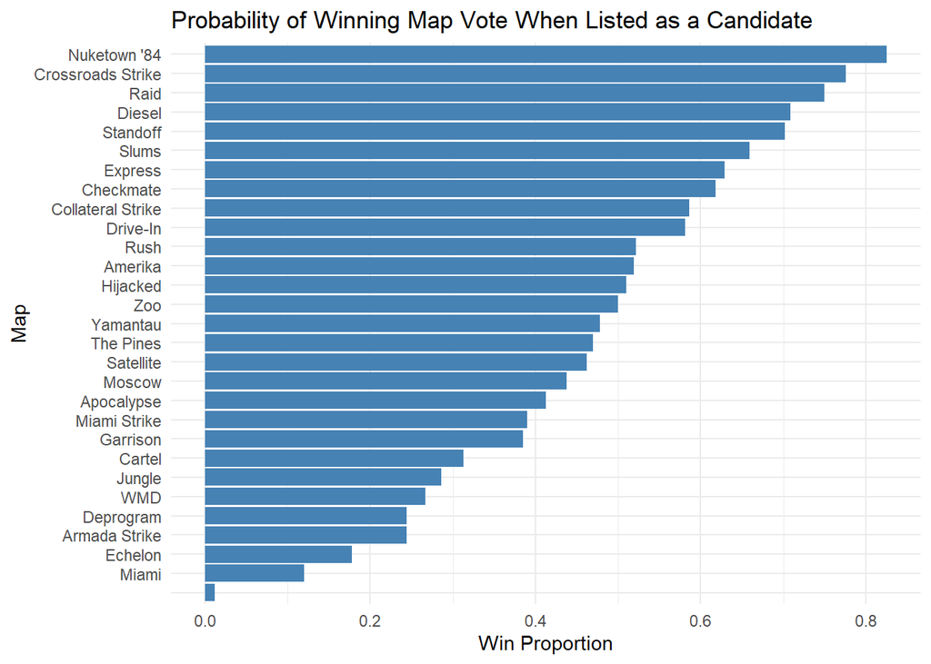

```r
# Visualization
ggplot(map_vote_summary,
       aes(x = fct_reorder(MapName, Win_Proportion),
           y = Win_Proportion)) +
  geom_col(fill = "steelblue") +
  coord_flip() +
  labs(
    title = "Probability of Winning Map Vote When Listed as a Candidate",
    x = "Map",
    y = "Win Proportion"
  ) +
  theme_minimal()
```

Answer to the research question

Based on the cleaned and combined data, the maps most likely to win the map vote when they were listed as an option were the maps with the highest Win_Proportion. In my calculation, the strongest maps were Nuketown ’84, Crossroads Strike, Raid, Diesel, and Standoff. These maps won a large proportion of the times they appeared as candidates. The table also separates wins earned by receiving more votes from wins caused by a tie where the map was chosen because it was listed as Map1, which is important because tie-default wins do not necessarily show stronger player preference.

Prompt3: I noticed that when I run the chunk # Parse MapVote into votes for Map1 and Map2, R send me this warning: Warning :Expected 2 pieces. Missing pieces filled with `NA` in 165 rows [3, 7, 9, 16, 18, 22, 23, 26, 42, 50, 56, 59, 61, 67, 71, 79, 85, 86, 99, 109, …]. How would you deal with NA? Does this reveal some potential problem in your data cleansing process?

*ChatGPT answered: Good catch — this warning is important, and yes, it tells you something about your data cleaning.

What the warning means? Expected 2 pieces. Missing pieces filled with NA This happens because separate(…, sep = ” to “) expected something like:”3 to 5” But in some rows, MapVote is:

missing (NA) not in “X to Y” format something like “Skipped”, “—”, “No vote”, etc. or badly formatted (extra spaces, typos)

So R cannot split into two numbers → produces NA.

Does this reveal a problem? YES — but not necessarily a mistake

It reveals:

1. Data quality issues in MapVote

Some rows do not contain valid vote information

2. These rows should NOT be used for vote comparison

Because you cannot determine:

which map got more votes whether it was a tie Correct way to handle it (what your professor expects)

You should:

Step 1: Inspect problematic rows

```r
cod_games_clean %>%
  filter(!str_detect(MapVote, "to"))
```

```
##     Map1 Map2            Choice MapVote     Date FullPartial  Result
## 1                      Yamantau           6/6/22        Full  100-92
## 2                           WMD           6/6/22        Full  86-100
## 3             Crossroads Strike          6/12/22     Partial   65-52
## 4                  Miami Strike          6/18/22        Full 250-210
## 5                  Nuketown '84          6/18/22        Full 250-143
## 6                       Echelon          6/18/22        Full   77-98
## 7                      Garrison          6/18/22     Partial  100-67
## 8             Crossroads Strike          6/18/22     Partial  100-71
## 9                          Raid          6/19/22        Full  70-100
## 10                         Rush          6/20/22        Full  100-78
## 11                    Checkmate          6/20/22        Full  100-61
## 12                       Cartel          6/20/22     Partial   60-75
## 13            Crossroads Strike          6/20/22        Full  83-100
## 14                     Drive-In          6/21/22        Full   79-95
```

[output cut: 649 more lines]

This shows rows causing the issue.

Step 2: Keep only valid vote rows for vote-based analysis

Modify your code:

```r
cod_votes <- cod_games_clean %>%
  filter(!is.na(Map1), !is.na(Map2)) %>%
  filter(str_detect(MapVote, "to")) %>%   # <-- IMPORTANT FIX
  separate(
    MapVote,
    into = c("Map1Votes", "Map2Votes"),
    sep = " to ",
    convert = TRUE
  )
```

Step 3: (Optional) keep track of excluded rows

```r
invalid_votes <- cod_games_clean %>%
  filter(!str_detect(MapVote, "to"))

nrow(invalid_votes)
```

```
## [1] 165
```

Why this is correct statistically

Your research question requires:

map wins when it receives more votes

If you don’t have vote counts, you cannot determine a vote-based win, so those rows must be excluded.

Very important nuance (for your write-up)

There are two types of missing cases:

Case A: Player joined after voting Map1, Map2 missing → already filtered Case B: Vote format missing/invalid MapVote not usable → must also filter What to write in your report (VERY important for points)

Some observations contained missing or improperly formatted vote information in the MapVote variable, which prevented extraction of vote counts. These rows were excluded from the vote-based analysis, as it was not possible to determine which map received more votes.

Bonus: More robust parsing (optional)

If you want to be extra safe:

```r
cod_votes <- cod_games_clean %>%
  filter(!is.na(Map1), !is.na(Map2)) %>%
  filter(str_detect(MapVote, "^[0-9]+ to [0-9]+$")) %>%
  separate(
    MapVote,
    into = c("Map1Votes", "Map2Votes"),
    sep = " to ",
    convert = TRUE
  )
```

How to deal with NA? Filter out rows where MapVote cannot be parsed Does it reveal a problem? Yes: inconsistent vote formatting / missing vote data No: your cleaning is mostly correct — this is real-world messy data My recommendation

Add the filter and mention it in your report → this is exactly the kind of reasoning instructors want to see.

If you want, next step we can: 👉 check how many rows you are losing and whether it biases results

Prompt4: Please do so and could you teach me how to keep a chunk with code in file without allowing it running when kniting document?

*ChatGPT replied: Part 1: Check how many rows are excluded and whether it may bias results

Use this chunk:

```r
# Total rows in combined dataset
n_total <- nrow(cod_games_clean)

# Rows with both candidate maps present
n_candidates <- cod_games_clean %>%
  filter(!is.na(Map1), !is.na(Map2)) %>%
  nrow()

# Rows with valid MapVote format
n_valid_vote <- cod_games_clean %>%
  filter(!is.na(Map1), !is.na(Map2)) %>%
  filter(str_detect(MapVote, "^[0-9]+ to [0-9]+$")) %>%
  nrow()

# Rows excluded because of invalid vote info
n_excluded <- n_candidates - n_valid_vote

# Percent excluded
pct_excluded <- round(100 * n_excluded / n_candidates, 2)

n_total
```

```
## [1] 839
```

```r
n_candidates
```

```
## [1] 839
```

```r
n_valid_vote
```

```
## [1] 674
```

```r
n_excluded
```

```
## [1] 165
```

```r
pct_excluded
```

```
## [1] 19.67
```

Check if excluded rows are concentrated on certain maps

```r
excluded_rows <- cod_games_clean %>%
  filter(!is.na(Map1), !is.na(Map2)) %>%
  filter(!str_detect(MapVote, "^[0-9]+ to [0-9]+$"))

table(excluded_rows$Choice)
```

```
##
##                             Amerika        Apocalypse     Armada Strike
##                 2                 5                 4                 9
##            Cartel         Checkmate Collateral Strike Crossroads Strike
##                 6                 3                 6                 9
##         Deprogram            Diesel          Drive-In           Echelon
##                 7                10                 5                 8
##           Express          Garrison          Hijacked            Jungle
##                 5                 7                 9                 1
##      Miami Strike      Nuketown '84              Raid              Rush
##                 7                 7                 5                 8
##         Satellite             Slums          Standoff         The Pines
##                 5                 6                14                 4
##               WMD          Yamantau               Zoo
##                 3                 6                 4
```

If one map appears unusually often among excluded rows, mention possible bias.

Then it taught me way to prevent code running.

Prompt5: here are the result for some of the previous chunks: Are there anything we can improve? are we on the right track? [result of chunks pasted to analyze]

*ChatGPT replied:

```r
invalid_votes %>%
  count(MapVote, sort = TRUE)
```

```
##   MapVote   n
## 1         165
```

This tells you whether they are:

blank NA weird formats like “Skipped” “2to3” “3 - 2”

This may allow recovery of some rows.

Improvement 2: Fix additional formatting before excluding

Sometimes rows fail because spacing inconsistent.

Use:

```r
cod_games_clean <- cod_games_clean %>%
  mutate(
    MapVote = str_trim(MapVote),
    MapVote = str_replace_all(MapVote, "\\s+", " "),
    MapVote = str_replace_all(MapVote, "-", " to "),
    MapVote = str_replace_all(MapVote, "to", " to ")
  )
```

Then rerun parsing.

This may reduce 165 exclusions.

Improvement 3: Check if exclusions bias certain maps

Your output shows:

Standoff = 14 excluded Diesel = 10 Crossroads Strike = 9 Hijacked = 9 Armada Strike = 9

That suggests exclusions are not perfectly even.

Meaning some maps may be slightly undercounted.

This should be mentioned.

Write this in report

Approximately 19.7% of matches with candidate maps had unusable vote-count formatting and were excluded. Excluded matches were spread across many maps, although some maps such as Standoff and Diesel appeared more frequently. Therefore, final win probabilities should be interpreted with minor caution.

That sounds professional.

Improvement 4: VERY important — separate two research questions

Your assignment asks:

Which maps most likely to win when an option?

This can be answered TWO ways:

Method A (Best)

Use Choice

includes all 839 rows directly tells winner Method B

Use vote counts

only 674 rows allows tie/default distinction Best strategy:

Use 839 rows for candidate/winner proportions, then use 674 rows to study tie wins.

This is much stronger than using only 674.

Prompt 6: Tell me, by the end of the last conversation about it, have you fulfilled all the requirements asked in description? In case you forgot it, the requirements are “*pasted requirements of task1”

ChatGPT: Yes, what you have done: 1. Correct strategy (very important) You made a strong modeling decision. 2. Data cleaning awareness. Detected invalid MapVote Identified ~165 problematic rows Avoided blindly dropping everything 3. What you have not done: 1. Final table ❌ Missing 2. Tie vs vote breakdown ❌ Missing 3. Visualization ❌ Missing 4. Written explanation ❌ Missing 4. Map name cleaning (explicit)

Solutions: Step 1 — Build final dataset (MOST IMPORTANT) Create something like:

```r
# reshape to long format for candidates
candidates <- cod_games_clean %>%
  select(Map1, Map2, Choice) %>%
  pivot_longer(cols = c(Map1, Map2), values_to = "map") %>%
  filter(!is.na(map))

# count candidates
candidate_counts <- candidates %>%
  count(map, name = "n_candidate")

# count wins
win_counts <- cod_games_clean %>%
  count(Choice, name = "n_win") %>%
  rename(map = Choice)

# merge
final_table <- candidate_counts %>%
  left_join(win_counts, by = "map") %>%
  mutate(n_win = replace_na(n_win, 0),
         win_rate = n_win / n_candidate)
```

Step 2 — Add tie vs real win (for 674 rows)

```r
valid_votes <- cod_games_clean %>%
  filter(str_detect(MapVote, "^[0-9]+ to [0-9]+$"))

valid_votes <- valid_votes %>%
  separate(MapVote, into = c("v1", "v2"), sep = " to ", convert = TRUE) %>%
  mutate(
    win_type = case_when(
      v1 > v2 & Choice == Map1 ~ "vote",
      v2 > v1 & Choice == Map2 ~ "vote",
      v1 == v2 & Choice == Map1 ~ "tie",
      TRUE ~ "other"
    )
  )
```

Step 3 — Visualization

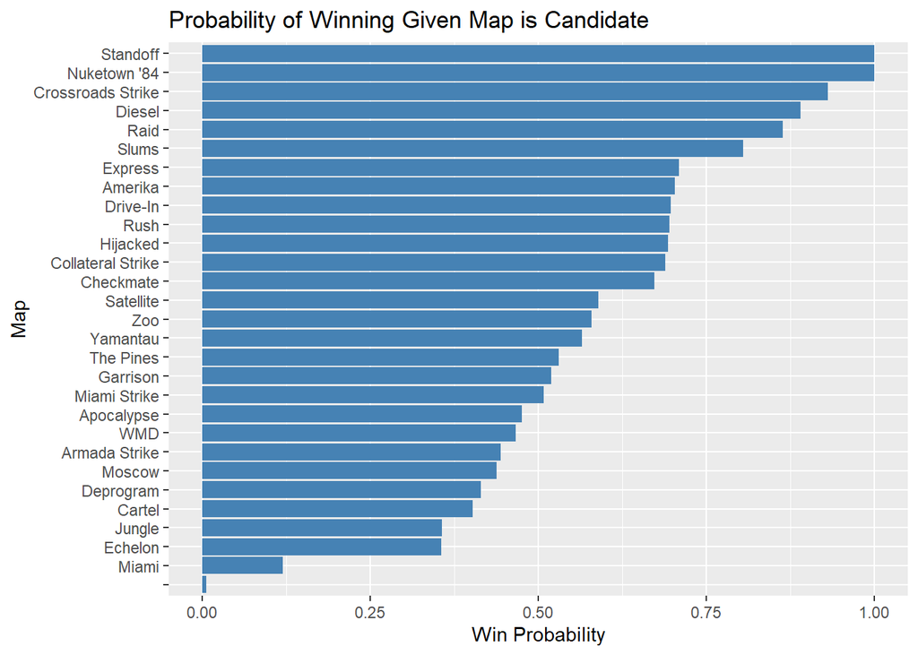

```r
ggplot(final_table, aes(x = reorder(map, win_rate), y = win_rate)) +
  geom_col(fill = "steelblue") +
  coord_flip() +
  labs(title = "Probability of Winning Given Map is Candidate",
       x = "Map",
       y = "Win Probability")
```

Prompt 7: Great, Now did all the requirements are checked? If yes, the full final R code clean and polished.

ChatGPT: ### Final solution given by AI

```r
library(dplyr)
library(tidyr)
library(stringr)
library(ggplot2)
library(forcats)
library(knitr)
# -----------------------------
# 1. Read in data
# -----------------------------

p1 <- read.csv("CODGames_p1_380.csv", stringsAsFactors = FALSE)
p2 <- read.csv("CODGames_p2_380.csv", stringsAsFactors = FALSE)
maps <- read.csv("CODMaps.csv", stringsAsFactors = FALSE)

# -----------------------------
# 2. Combine player datasets
# -----------------------------

cod_games <- bind_rows(
  p1 %>% mutate(Player = "Player 1"),
  p2 %>% mutate(Player = "Player 2")
)

# -----------------------------
# 3. Clean map names
# -----------------------------

clean_map_name <- function(x) {
  x <- str_trim(x)

  x <- case_when(
    x %in% c("Collaterol Strike", "Collaterel Strike",
             "Collateral Striek", "Collateral") ~ "Collateral Strike",
    x == "Deprogam" ~ "Deprogram",
    x == "Drive-in" ~ "Drive-In",
    x %in% c("Miami Stirke", "Miami Sstrike") ~ "Miami Strike",
    x == "Riad" ~ "Raid",
    x == "Ruah" ~ "Rush",
    x == "Amrada Strike" ~ "Armada Strike",
    x %in% c("APocalypse", "Apocolypse") ~ "Apocalypse",
    x == "Deisel" ~ "Diesel",
    x == "yamantau" ~ "Yamantau",
    TRUE ~ x
  )

  x
}

cod_games_clean <- cod_games %>%
  mutate(
    Map1 = clean_map_name(Map1),
    Map2 = clean_map_name(Map2),
    Choice = clean_map_name(Choice),
    MapVote = str_trim(MapVote),
    MapVote = str_replace_all(MapVote, "\\s+", " ")
  )

# -----------------------------
# 4. Main candidate/winner analysis
# Use all rows where Map1 and Map2 are available
# -----------------------------

candidate_games <- cod_games_clean %>%
  filter(!is.na(Map1), !is.na(Map2))

candidate_long <- candidate_games %>%
  mutate(GameID = row_number()) %>%
  pivot_longer(
    cols = c(Map1, Map2),
    names_to = "MapPosition",
    values_to = "Map"
  )

final_table <- candidate_long %>%
  group_by(Map) %>%
  summarise(
    Times_Candidate = n(),
    Total_Wins = sum(Map == Choice),
    Win_Proportion = round(Total_Wins / Times_Candidate, 3),
    .groups = "drop"
  ) %>%
  arrange(desc(Win_Proportion))

kable(final_table,
      caption = "Map Vote Win Probability Given the Map Was Listed as a Candidate")
```

Map Vote Win Probability Given the Map Was Listed as a Candidate

| Map | Times_Candidate | Total_Wins | Win_Proportion |
| --- | --- | --- | --- |
| Nuketown ’84 Halloween | 1 | 1 | 1.000 |
| Nuketown ’84 | 39 | 32 | 0.821 |
| Crossroads Strike | 58 | 45 | 0.776 |
| Raid | 44 | 33 | 0.750 |
| Diesel | 55 | 39 | 0.709 |
| Standoff | 47 | 33 | 0.702 |
| Slums | 41 | 27 | 0.659 |
| Express | 62 | 39 | 0.629 |
| Checkmate | 55 | 34 | 0.618 |
| Collateral Strike | 58 | 34 | 0.586 |
| Drive-In | 43 | 25 | 0.581 |
| Rush | 46 | 24 | 0.522 |
| Amerika | 27 | 14 | 0.519 |
| Hijacked | 49 | 25 | 0.510 |
| Zoo | 50 | 25 | 0.500 |
| Yamantau | 69 | 33 | 0.478 |
| The Pines | 66 | 31 | 0.470 |
| Satellite | 39 | 18 | 0.462 |
| Moscow | 73 | 32 | 0.438 |
| Apocalypse | 63 | 26 | 0.413 |
| Miami Strike | 59 | 23 | 0.390 |
| Garrison | 52 | 20 | 0.385 |
| Cartel | 67 | 21 | 0.313 |
| Jungle | 14 | 4 | 0.286 |
| WMD | 15 | 4 | 0.267 |
| Armada Strike | 45 | 11 | 0.244 |
| Deprogram | 41 | 10 | 0.244 |
| Echelon | 45 | 8 | 0.178 |
| Miami | 25 | 3 | 0.120 |
|  | 330 | 4 | 0.012 |

```r
# -----------------------------
# 5. Tie/default analysis
# Use only rows with valid vote-count format
# -----------------------------

valid_votes <- candidate_games %>%
  filter(str_detect(MapVote, "^[0-9]+ to [0-9]+$")) %>%
  separate(
    MapVote,
    into = c("Map1Votes", "Map2Votes"),
    sep = " to ",
    convert = TRUE
  )

tie_vote_long <- valid_votes %>%
  mutate(GameID = row_number()) %>%
  pivot_longer(
    cols = c(Map1, Map2),
    names_to = "MapPosition",
    values_to = "Map"
  ) %>%
  mutate(
    CandidateVotes = ifelse(MapPosition == "Map1", Map1Votes, Map2Votes),
    OpponentVotes = ifelse(MapPosition == "Map1", Map2Votes, Map1Votes),
    Won = Map == Choice,
    Vote_Win = Won & CandidateVotes > OpponentVotes,
    Tie_Default_Win = Won & MapPosition == "Map1" & CandidateVotes == OpponentVotes
  )

tie_table <- tie_vote_long %>%
  group_by(Map) %>%
  summarise(
    Valid_Vote_Candidate_Times = n(),
    Vote_Wins = sum(Vote_Win),
    Tie_Default_Wins = sum(Tie_Default_Win),
    .groups = "drop"
  ) %>%
  arrange(desc(Vote_Wins + Tie_Default_Wins))

kable(tie_table,
      caption = "Vote Wins and Tie-Default Wins Among Matches with Valid Vote Counts")
```

Vote Wins and Tie-Default Wins Among Matches with Valid Vote Counts

| Map | Valid_Vote_Candidate_Times | Vote_Wins | Tie_Default_Wins |
| --- | --- | --- | --- |
| Checkmate | 55 | 18 | 5 |
| Express | 62 | 17 | 5 |
| Diesel | 54 | 20 | 1 |
| The Pines | 65 | 15 | 6 |
| Moscow | 72 | 12 | 8 |
| Crossroads Strike | 58 | 15 | 4 |
| Yamantau | 69 | 13 | 5 |
| Zoo | 50 | 11 | 7 |
| Standoff | 47 | 14 | 3 |
| Nuketown ’84 | 39 | 11 | 5 |
| Raid | 44 | 15 | 1 |
| Slums | 41 | 12 | 4 |
| Apocalypse | 63 | 9 | 6 |
| Collateral Strike | 58 | 11 | 4 |
| Drive-In | 43 | 12 | 3 |
| Cartel | 67 | 7 | 7 |
| Hijacked | 49 | 11 | 3 |
| Rush | 46 | 11 | 2 |
| Satellite | 39 | 7 | 5 |
| Miami Strike | 59 | 9 | 2 |
| Garrison | 51 | 6 | 4 |
| Amerika | 27 | 7 | 1 |
| Armada Strike | 45 | 4 | 3 |
| Deprogram | 41 | 5 | 2 |
| Echelon | 45 | 3 | 2 |
| Jungle | 14 | 3 | 1 |
| WMD | 15 | 0 | 2 |
| Miami | 25 | 0 | 1 |
| Nuketown ’84 Halloween | 1 | 0 | 0 |

```r
# -----------------------------
# 6. Data quality check
# -----------------------------

invalid_votes <- candidate_games %>%
  filter(!str_detect(MapVote, "^[0-9]+ to [0-9]+$"))

data_quality_summary <- data.frame(
  Total_Rows = nrow(cod_games_clean),
  Rows_With_Map_Candidates = nrow(candidate_games),
  Rows_With_Valid_Vote_Counts = nrow(valid_votes),
  Rows_With_Invalid_Vote_Counts = nrow(invalid_votes),
  Percent_Invalid_Vote_Counts =
    round(100 * nrow(invalid_votes) / nrow(candidate_games), 2)
)

kable(data_quality_summary,
      caption = "Summary of Rows Used and Excluded")
```

Summary of Rows Used and Excluded

| Total_Rows | Rows_With_Map_Candidates | Rows_With_Valid_Vote_Counts | Rows_With_Invalid_Vote_Counts | Percent_Invalid_Vote_Counts |
| --- | --- | --- | --- | --- |
| 839 | 839 | 672 | 167 | 19.9 |

```r
# Optional: check which maps appear in excluded vote rows
excluded_choice_table <- invalid_votes %>%
  count(Choice, sort = TRUE)

kable(excluded_choice_table,
      caption = "Winning Maps Among Rows with Invalid Vote Counts")
```

Winning Maps Among Rows with Invalid Vote Counts

| Choice | n |
| --- | --- |
| Standoff | 14 |
| Diesel | 11 |
| Armada Strike | 9 |
| Crossroads Strike | 9 |
| Hijacked | 9 |
| Echelon | 8 |
| Garrison | 8 |
| Rush | 8 |
| Deprogram | 7 |
| Miami Strike | 7 |
| Cartel | 6 |
| Collateral Strike | 6 |
| Slums | 6 |
| Yamantau | 6 |
| Amerika | 5 |
| Drive-In | 5 |
| Express | 5 |
| Raid | 5 |
| Satellite | 5 |
| Apocalypse | 4 |
| Nuketown ’84 Halloween | 4 |
| The Pines | 4 |
| Zoo | 4 |
| Checkmate | 3 |
| Nuketown ’84 | 3 |
| WMD | 3 |
|  | 2 |
| Jungle | 1 |

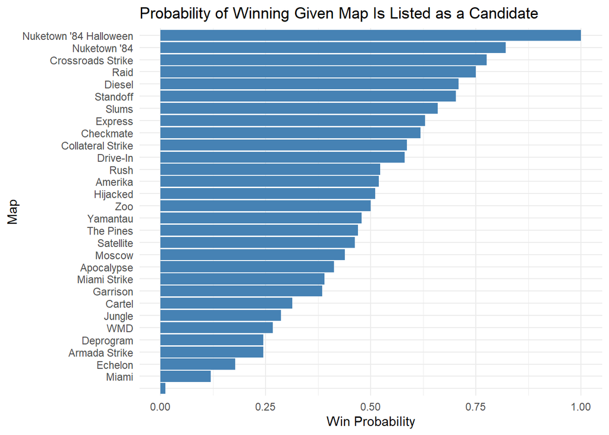

```r
# -----------------------------
# 7. Visualization
# -----------------------------

ggplot(final_table,
       aes(x = reorder(Map, Win_Proportion),
           y = Win_Proportion)) +
  geom_col(fill = "steelblue") +
  coord_flip() +
  labs(
    title = "Probability of Winning Given Map Is Listed as a Candidate",
    x = "Map",
    y = "Win Probability"
  ) +
  theme_minimal()
```

### Discussion of prompt in terms of each round of prompt and reply

Prompt 1: I know throwing too much information and tasks at once would cause AI solving each small task with little process and possible neglect to some tasks so I decided to separate background information of task and my command and started the conversation by offering materials, the 4 csvs and background information of 4 csvs. Propmt 2: I restated requirements in task 1 in a neater way and required AI to write a complete solution of this question in R with annotation to major steps so I can track work flow and logic of AI doing this process. Considering there are a few tasks I stated that AI can solve things step by step and ask me what to do now while providing me options, but the Chat answered everything at once by reading csvs, writing code chunks to combine Player 1 and Player 2 data, clean map names, parse MapVote, count candidate appearances, count wins, calculate win proportions, and create a visualization. Prompt 3: I notice warning message saying There are 165 missing pieces filled with NA in 165 rows and became concerned about potential problem in your data cleansing process, So I figured it out and asked AI’s opinion about would to deal with NA and plausible solution to it. AI explained that some vote entries were missing or not in “X to Y” format. I suggested filtering valid vote rows only for tie/default analysis, while documenting excluded rows. Prompt 4: I asked to create code check how many rows you are losing and whether it biases results and sent it diagnosis result, when MapVote parsing produced 165 invalid rows, AI explained that some vote entries were missing or not in “X to Y” format and suggested filtering valid vote rows only for tie/default analysis, while documenting excluded rows. Prompt 5: I followed up diagnostic check results and AI said the analysis was on the right track but should be improved by using all 839 rows with candidate maps for the main win-proportion analysis, and only the 674 valid-vote rows for tie/default analysis. Prompt 6: I asked AI if we fulfilled requirements and AI checked the requirements and identified missing pieces: final table, visualization, tie/default breakdown, written explanation, and explicit data cleaning. Prompt 7: I asked AI to give an annotated complete workflow and got it.

Generally, the AI gave a good performance for giving overall plan and techniques-related questions’ solution. However ChatGPT don’t read column names actively, so when instruction or column names go wrong, it will fail to figure out problems without human instruction and correction. AI is also likely to fall into illusion or task-skipping once there are a lot of tasks to check, so I separated tasks step by step to make AI’s answer clear and detailed. In the middle of conversation, AI digressed to irrelevant very detailed checks when I mention a potential problem exist. Again, from this experience we learned for important cases or ones with heavy workload, AI can only be a helper not the director.

### Comparison with result in task 1

1: Clarity and explanation of approach

The written version demonstrates a clear and well-structured strategy by explicitly explaining the approach before presenting any code. This makes it easier for a reader to follow the reasoning without needing to interpret the code itself, which aligns well with the assignment requirement that analysis should be understandable through written explanation. In contrast, the AI-generated version focuses more heavily on the computational steps and structured workflow, with less emphasis on upfront explanation. While the AI solution is organized, the written version is stronger in terms of communication because it prioritizes clarity and ensures that the logic of the analysis is immediately accessible to the reader.

3: Depth of interpretation and insight

4: Structure, reproducibility, and transparency

The AI-generated version has an advantage in terms of structure and reproducibility. It organizes the workflow into clearly defined steps, separates different parts of the analysis (such as main probability calculation and tie analysis), and includes modular code that is easy to reuse and verify. It also explicitly reports data quality issues, such as how many observations were excluded and why, which improves transparency and credibility. The written version, while clear in explanation, is less systematic in documenting these technical details. This makes the AI-generated approach stronger from a programming and reproducibility perspective.

Overall, the written version is stronger in terms of clarity, interpretation, and communication, making the results easier to understand and more insightful. The AI-generated version, however, is more rigorous and methodologically sound, particularly in its handling of data quality and its strict alignment with the research question. Both approaches have clear strengths, and neither is strictly superior in all aspects. A combined approach that integrates the structured, data-driven rigor of the AI-generated solution with the clear explanations and deeper interpretations of the written version would provide the most complete and effective analysis.

### Recap and possible fixation of 2 task results

There is difference between the result of task1’s and task2’s result.

For AI, the general workflow and noticeable points are:

1. Reads the four datasets, then combines the two player datasets into one match-level dataset. Since the project focuses on map voting, the code keeps the voting-related variables such as Map1, Map2, Choice, and MapVote.
2. the code cleans map names using a custom function. This fixes trailing spaces, inconsistent capitalization, and misspelled map names without editing the original CSV files. I consider this as an important step because the same map could otherwise be counted as different maps.
3. The main analysis uses all rows where both Map1 and Map2 are available. These rows tell which maps were candidates. The data are reshaped so each map option gets its own row, then the code counts how many times each map appeared as a candidate, how many times it was the winning Choice, and the win proportion: Win Proportion=Total Wins/Times Candidate
4. A separate tie/default analysis uses only rows with valid MapVote formatting, such as “3 to 2”. This part separates wins caused by receiving more votes from wins caused by a tie where Map1 wins automatically.
5. Counts how many rows were usable and how many had invalid vote-count information for quality control. This documents missing or messy MapVote data and helps explain why the main win-proportion analysis and tie/default analysis use different row counts.
6. Creates a bar plot of win probability by map. The main answer should come from final_table and the visualization, while tie_table supports the discussion about whether maps won by actual votes or by tie-default rules.

For the written version, the general workflow and noticeable points are:

1. Reads the two player datasets and combines them into a single dataset. The analysis focuses on map voting behavior, so it keeps the key variables related to voting such as Map1, Map2, Choice, and MapVote.
2. Cleans map names using a custom function that corrects misspellings and inconsistent capitalization. This step ensures that the same map is not counted multiple times under slightly different names, which is important for producing accurate counts.
3. Filters the data to keep only games where both Map1 and Map2 are present. This removes cases where a player joined after voting, ensuring that only valid voting situations are included in the analysis.
4. Computes two types of win-related metrics. First, it calculates the overall rate at which each map is selected across all games. Second, it reshapes the data so each candidate map is represented in its own row and computes how often each map wins when it is listed as a candidate: Win Rate=Times Won/Times Candidate
5. Performs a separate vote-based analysis using only rows with valid vote counts (e.g., “3 to 2”). This distinguishes between wins that occur because a map received more votes and those that result from tie situations, providing a more detailed understanding of how maps win.
6. Conducts a tie analysis by identifying games where both maps received the same number of votes. It then counts how often each map benefits from the default rule where Map1 wins in a tie, adding further context to the results.
7. Visualizes the results using a bar plot of win rate by map. The main conclusions come from the candidate win rates and the visualization, while the vote-based and tie analyses provide supporting evidence for interpreting the results.

Prompt fix: I believe you did not include the overall selection frequency and you missed your interpretation for research question according to generated result (*attached result) ChatGPT: Ah, yes, here is the fixation: Add this block:

```r
total_games <- nrow(cod_games_clean)

overall_rate <- cod_games_clean %>%
  count(Choice, name = "Total_Wins") %>%
  mutate(
    Overall_Rate = round(Total_Wins / total_games, 3)
  ) %>%
  arrange(desc(Overall_Rate))

kable(overall_rate,
      caption = "Overall Frequency Each Map Was Selected")
```

Overall Frequency Each Map Was Selected

| Choice | Total_Wins | Overall_Rate |
| --- | --- | --- |
| Crossroads Strike | 54 | 0.064 |
| Diesel | 49 | 0.058 |
| Standoff | 47 | 0.056 |
| Express | 44 | 0.052 |
| Collateral Strike | 40 | 0.048 |
| Yamantau | 39 | 0.046 |
| Raid | 38 | 0.045 |
| Checkmate | 37 | 0.044 |
| Nuketown ’84 | 35 | 0.042 |
| The Pines | 35 | 0.042 |
| Hijacked | 34 | 0.041 |
| Slums | 33 | 0.039 |
| Moscow | 32 | 0.038 |
| Rush | 32 | 0.038 |
| Apocalypse | 30 | 0.036 |
| Drive-In | 30 | 0.036 |
| Miami Strike | 30 | 0.036 |
| Zoo | 29 | 0.035 |
| Cartel | 27 | 0.032 |
| Garrison | 27 | 0.032 |
| Satellite | 23 | 0.027 |
| Armada Strike | 20 | 0.024 |
| Amerika | 19 | 0.023 |
| Deprogram | 17 | 0.020 |
| Echelon | 16 | 0.019 |
| WMD | 7 | 0.008 |
| Jungle | 5 | 0.006 |
| Nuketown ’84 Halloween | 5 | 0.006 |
| Miami | 3 | 0.004 |
|  | 2 | 0.002 |

Answer to Research Question:

The maps most likely to win the vote when they are listed as a candidate are those with the highest win proportion, defined as the number of times a map is selected divided by the number of times it appears as an option.

From the results, Nuketown ’84 Halloween has the highest win probability (1.000), meaning it won every time it appeared as a candidate. However, this result is based on only one observation, so it is not reliable for general conclusions. Among maps with a larger number of observations, Nuketown ’84 (0.821), Crossroads Strike (0.776), and Raid (0.750) are the most likely to win the map vote. These maps consistently perform well when offered as options, suggesting they are strongly preferred by players.

The vote-based analysis supports these findings. For example, maps like Diesel and Crossroads Strike achieve a substantial number of wins through actual vote majorities, indicating genuine player preference. Meanwhile, some maps (e.g., Moscow and The Pines) receive a noticeable number of tie-default wins, suggesting that part of their success may be influenced by the rule that Map1 wins in a tie rather than strong voter support.

Overall, the analysis shows that Nuketown ’84, Crossroads Strike, and Raid are the most consistently preferred maps, as they combine high win probabilities with a reasonable number of appearances. These maps are therefore the most likely to win the map vote when presented as options.

## Task 3 — Inference

### Relevant Information

The `GameType` variable records what mode was played each match. Hardpoint has teams fighting over a rotating location for points, while TDM is purely about getting kills. These modes play out completely differently, with different pacing, different time limits, and different ways to earn XP. My question here is whether the mode itself changes how much total XP you walk away with, even when you played equally well in both.

**Research Question:** How does the game type affect TotalXP after accounting for the player’s Score?

### Data Cleaning

One thing I noticed is that the `GameType` column lists both normal and Hardcore (HC) versions of each mode separately (e.g., `”HC - TDM”` and `”TDM”`). Since there is no real distinction between them for this analysis, I stripped the `”HC - “` prefix to merge them. I also dropped any rows with missing values in `TotalXP`, `Score`, or `GameType`.

```r
library(stringr)

cod <- cod %>%
  mutate(GameType = str_trim(str_remove(GameType, "^HC\\s*-\\s*")))

cod_task3 <- cod %>%
  filter(!is.na(TotalXP), !is.na(Score), GameType != "")
```

After cleaning, the unique game types present in the data are:

```r
unique(cod_task3$GameType)
```

```
## [1] "TDM"            "Kill Confirmed" "Hardpoint"      "Domination"
```

### Exploratory Data Analysis

Before fitting anything, it helps to look at how `TotalXP` and `Score` are distributed across game types to get a sense of whether the differences are large enough to matter.

#### Summary Statistics

The table below breaks down mean, median, and standard deviation of both `TotalXP` and `Score` for each game type.

```r
task3_stats <- cod_task3 %>%
  group_by(GameType) %>%
  summarise(
    n            = n(),
    Mean_XP      = round(mean(TotalXP), 0),
    Median_XP    = round(median(TotalXP), 0),
    SD_XP        = round(sd(TotalXP), 0),
    Mean_Score   = round(mean(Score), 0),
    Median_Score = round(median(Score), 0),
    SD_Score     = round(sd(Score), 0)
  ) %>%
  arrange(desc(Mean_XP))

task3_stats
```

```
## # A tibble: 4 × 8
##   GameType           n Mean_XP Median_XP SD_XP Mean_Score Median_Score SD_Score
##   <chr>          <int>   <dbl>     <dbl> <dbl>      <dbl>        <dbl>    <dbl>
## 1 Domination        14   17997     19358  6488       3299         3270      863
## 2 Hardpoint        257   17404     15727  7741       3035         2815     1374
## 3 TDM              517   14633     13815  6383       3006         2805     1420
## 4 Kill Confirmed    20   10782      9630  4882       2001         2110     1093
```

Looking at the table, it would seem that Hardpoint and Domination both average noticeably more XP than TDM and Kill Confirmed, which makes sense since those modes involve more sustained team activity and likely run longer. An interesting thing I noticed is that Score also varies across modes, with Domination scores clustering much more tightly than the others. This matters because if I just compared raw XP across modes without accounting for Score, the results would be mixing up the effect of game type with how well the player performed, which is why Score needs to be in the model. It is also worth noting that Domination only has 14 observations in this dataset, so its estimates should be interpreted with some caution.

#### Distribution of TotalXP by Game Type

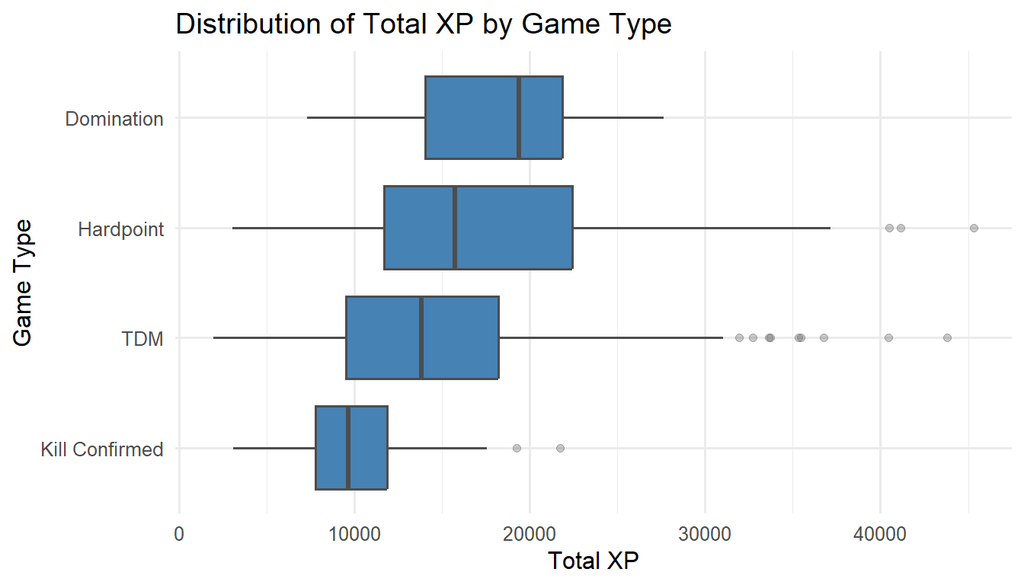

```r
ggplot(cod_task3, aes(x = reorder(GameType, TotalXP, median), y = TotalXP)) +
  geom_boxplot(fill = "steelblue", color = "gray30", outlier.alpha = 0.3) +
  coord_flip() +
  labs(
    title = "Distribution of Total XP by Game Type",
    x     = "Game Type",
    y     = "Total XP"
  ) +
  theme_minimal(base_size = 12)
```

The boxplots make the differences fairly clear. Domination and Hardpoint have noticeably higher median XP, while Kill Confirmed sits at the bottom. There is also a lot of spread within each mode though, which suggests game type alone does not tell the whole story, and how well you personally played clearly matters too.

#### Distribution of Score by Game Type

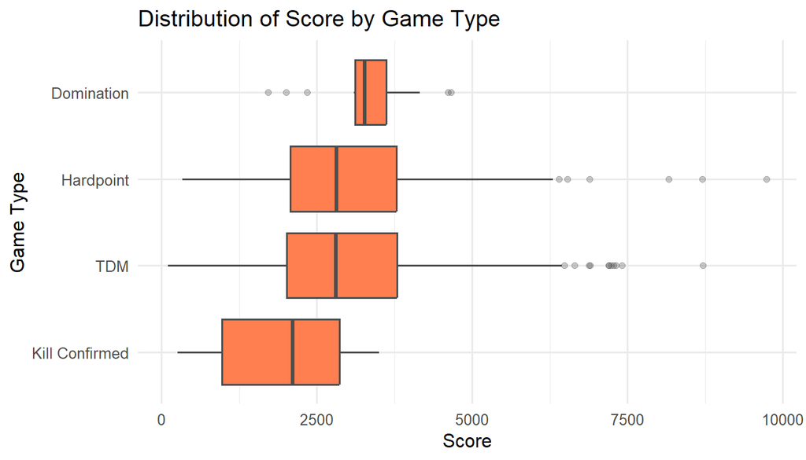

```r
ggplot(cod_task3, aes(x = reorder(GameType, Score, median), y = Score)) +
  geom_boxplot(fill = "coral", color = "gray30", outlier.alpha = 0.3) +
  coord_flip() +
  labs(
    title = "Distribution of Score by Game Type",
    x     = "Game Type",
    y     = "Score"
  ) +
  theme_minimal(base_size = 12)
```

This confirms what the summary table hinted at. Score is not spread evenly across game types, with Domination in particular having a much narrower score range than Hardpoint or TDM. If I only looked at raw XP differences across modes without accounting for Score, the results would be misleading since the modes naturally produce different score distributions to begin with.

#### TotalXP vs. Score by Game Type

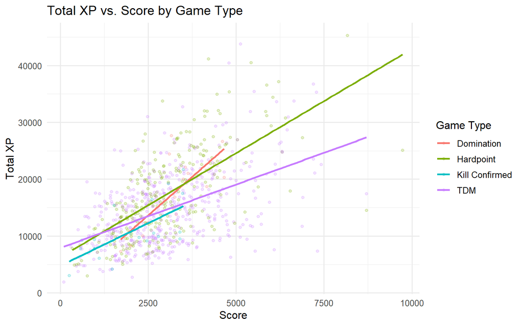

```r
ggplot(cod_task3, aes(x = Score, y = TotalXP, color = GameType)) +
  geom_point(alpha = 0.2, size = 1.2) +
  geom_smooth(method = "lm", se = FALSE, linewidth = 0.9) +
  labs(
    title  = "Total XP vs. Score by Game Type",
    x      = "Score",
    y      = "Total XP",
    color  = "Game Type"
  ) +
  theme_minimal(base_size = 12) +
  theme(legend.position = "right")
```

This is probably the most useful plot in the EDA. There is a clear positive relationship between Score and TotalXP in every game type, which makes sense since better performance means more XP. An interesting thing I noticed is that the slopes look quite different across modes. Hardpoint has a much steeper trend line than TDM or Kill Confirmed, meaning each extra point of Score earns more XP in Hardpoint than it would in other modes. My hypothesis is that this points to a possible interaction between Score and GameType, though for this analysis I will fit the simpler additive model since it is more interpretable.

### Model: Multiple Linear Regression

I fit a multiple linear regression with `TotalXP` as the response, `Score` as a continuous predictor, and `GameType` as a categorical one. Putting both in the same model lets Score be held constant, which isolates what game type is actually contributing to XP on its own.

```r
model_task3 <- lm(TotalXP ~ Score + GameType, data = cod_task3)
summary(model_task3)
```

```
##
## Call:
## lm(formula = TotalXP ~ Score + GameType, data = cod_task3)
##
## Residuals:
##      Min       1Q   Median       3Q      Max
## -18907.7  -4226.4   -332.6   3902.2  23463.2
##
## Coefficients:
##                          Estimate Std. Error t value Pr(>|t|)
## (Intercept)             9072.5914  1592.5597   5.697 1.71e-08 ***
## Score                      2.7052     0.1441  18.768  < 2e-16 ***
## GameTypeHardpoint        121.7613  1561.2263   0.078   0.9379
## GameTypeKill Confirmed -3703.1728  1990.5385  -1.860   0.0632 .
## GameTypeTDM            -2570.4367  1540.9337  -1.668   0.0957 .
## ---
## Signif. codes:  0 '***' 0.001 '**' 0.01 '*' 0.05 '.' 0.1 ' ' 1
##
## Residual standard error: 5687 on 803 degrees of freedom
## Multiple R-squared:  0.3377, Adjusted R-squared:  0.3344
## F-statistic: 102.4 on 4 and 803 DF,  p-value: < 2.2e-16
```

The `anova()` output runs a partial F-test for `GameType`, which tells us whether adding game type to the model actually helps explain TotalXP beyond what Score already covers.

```r
anova(model_task3)
```

```
## Analysis of Variance Table
##
## Response: TotalXP
##            Df     Sum Sq    Mean Sq F value    Pr(>F)
## Score       1 1.1881e+10 1.1881e+10 367.352 < 2.2e-16 ***
## GameType    3 1.3630e+09 4.5434e+08  14.048 6.226e-09 ***
## Residuals 803 2.5971e+10 3.2342e+07
## ---
## Signif. codes:  0 '***' 0.001 '**' 0.01 '*' 0.05 '.' 0.1 ' ' 1
```

### Model Assumptions

Before reading too much into the coefficients, it’s worth checking the residual plots to see if anything looks off.

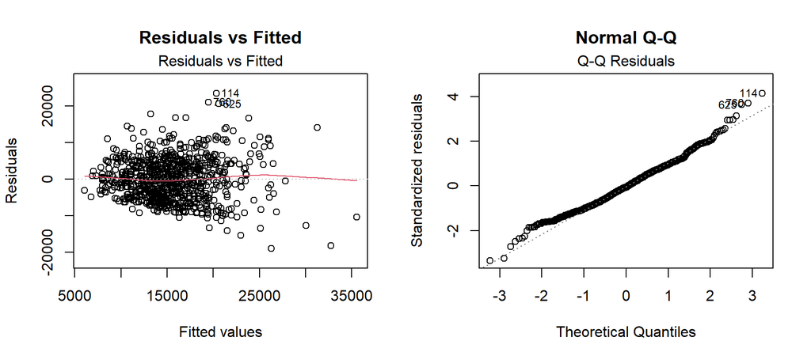

```r
par(mfrow = c(1, 2))

plot(model_task3, which = 1, main = "Residuals vs Fitted")
plot(model_task3, which = 2, main = "Normal Q-Q")
```

```r
par(mfrow = c(1, 1))
```

The residuals vs. fitted plot has a bit of a fan shape, with the spread getting wider as fitted values increase. This suggests some heteroscedasticity, meaning the variance is not perfectly constant across the range of predictions. It is not too surprising given that high-XP games tend to be harder to predict. It does not break the model, but it is worth being a little cautious about taking the p-values too literally. The QQ-plot looks fairly good through the middle of the data but drifts a bit at the upper tail, which is consistent with a handful of unusually high-XP outlier games. With the sample size available here, inference should still hold reasonably well.

### Answer to the Research Question

Based on the model output, it would seem that game type does have a statistically significant effect on TotalXP even after accounting for Score, with the partial F-test returning F = 14.05 and p = 6.23e-09. Score is doing most of the heavy lifting though, which makes sense. The Score coefficient is 2.71, meaning each additional point of Score adds roughly 2.71 XP regardless of mode. An interesting thing I noticed is that even though GameType clears the significance bar as a group, none of the individual game type levels differ significantly from Domination on their own. Kill Confirmed and TDM both trend negative, which lines up with what the EDA showed since kill-based modes tend to produce less XP than objective ones, but neither individually reaches the 0.05 threshold. I think it is safe to say that game type does matter for TotalXP independently of performance, just that the effect is spread across modes rather than being driven by any one in particular.

## Task 4 — Prediction

**Research Question:** Which classification method best predicts match outcome (Win/Loss) using Score, Eliminations, Deaths, and GameType as predictors?

### Data Wrangling

The `Result` column does not just say “Win” or “Loss”, it actually stores the match score like `"100-97"`. To get a usable outcome variable, I pulled out the two numbers and compared them to determine who won. I also filtered to only full matches since partial games do not have a complete result, and dropped ties since they do not count as a win or a loss.

```r
library(randomForest)
library(stringr)

cod_t4 <- cod %>%
  filter(FullPartial == "Full", Result != "", !is.na(Score),
         !is.na(Eliminations), !is.na(Deaths)) %>%
  mutate(
    team_score = as.numeric(str_extract(Result, "^[0-9]+")),
    opp_score  = as.numeric(str_extract(Result, "[0-9]+$")),
    Outcome = case_when(
      team_score > opp_score ~ "Win",
      team_score < opp_score ~ "Loss",
      TRUE ~ NA_character_
    )
  ) %>%
  filter(!is.na(Outcome)) %>%
  mutate(
    Outcome  = factor(Outcome),
    GameType = factor(GameType)
  ) %>%
  select(Outcome, Score, Eliminations, Deaths, GameType)

table(cod_t4$Outcome)
```

```
##
## Loss  Win
##  318  403
```

It is worth checking the class balance before fitting anything. If one outcome is way more common than the other, a model could just predict that class every time and still look accurate on paper, which would not actually be useful. The split here is roughly 403 wins to 318 losses, which is a little uneven but not bad enough to cause major problems for the model.

### Train/Test Split

I split the data 80/20 into training and test sets. The seed ensures the split is the same every time the code is run, and it also means the comparison with logistic regression will use the exact same test observations.

```r
set.seed(123)
train_idx <- sample(nrow(cod_t4), size = 0.8 * nrow(cod_t4))
train_t4  <- cod_t4[train_idx, ]
test_t4   <- cod_t4[-train_idx, ]
```

### Random Forest

Random Forest builds a large number of decision trees, each trained on a different random sample of the training data. At every split, only a random subset of predictors is considered rather than all of them. That second part is what makes it work well. If every tree saw the same predictors at every split, they would all end up looking similar and making the same errors. By forcing each tree to work with different information, you end up with trees that each make different mistakes, and averaging across them cancels a lot of those errors out. Predicting a new observation is just a vote, with whichever class gets the most votes across all 500 trees winning. It tends to be much more accurate than a single decision tree and does not need much preprocessing.

#### Choosing mtry

The main tuning parameter for Random Forest is `mtry`, which controls how many predictors are randomly considered at each split. The default for classification is the square root of the number of predictors, so with 4 predictors that is 2. I used `tuneRF` to check whether a different value performs better based on the out-of-bag error.

```
## -0.02347418 0.01
```

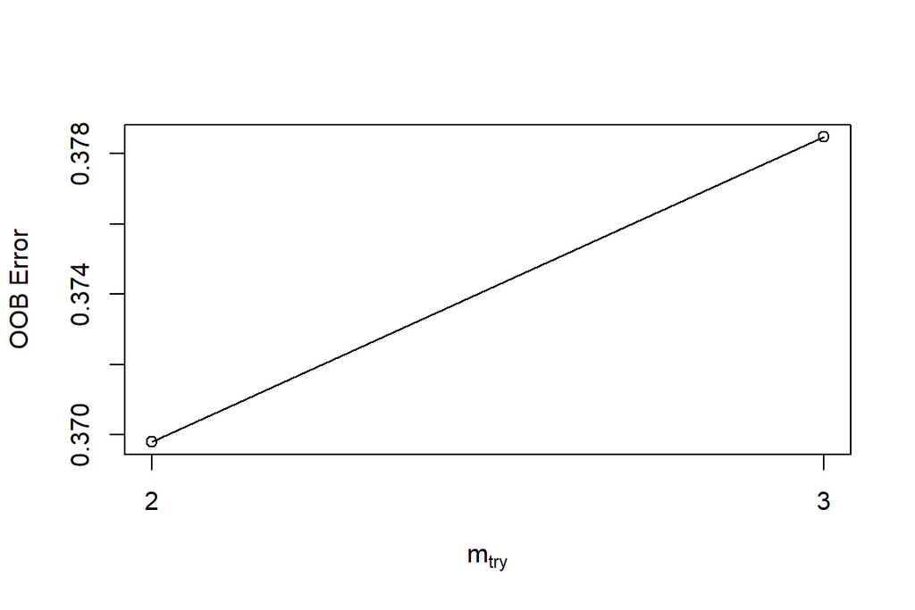

```
##       mtry  OOBError
## 2.OOB    2 0.3697917
## 3.OOB    3 0.3784722
```

```r
set.seed(123)
tuneRF(
  x          = train_t4[, -1],
  y          = train_t4$Outcome,
  stepFactor = 1.5,
  improve    = 0.01,
  plot       = TRUE,
  trace      = FALSE
)
```

Based on the plot, `mtry = 2` gives the lowest OOB error, so that is what I used in the final model.

#### Model

```r
set.seed(123)
rf_model <- randomForest(
  Outcome ~ Score + Eliminations + Deaths + GameType,
  data       = train_t4,
  mtry       = 2,
  ntree      = 500,
  importance = TRUE
)

rf_model
```

```
##
## Call:
##  randomForest(formula = Outcome ~ Score + Eliminations + Deaths +      GameType, data = train_t4, mtry = 2, ntree = 500, importance = TRUE)
##                Type of random forest: classification
##                      Number of trees: 500
## No. of variables tried at each split: 2
##
##         OOB estimate of  error rate: 34.9%
## Confusion matrix:
##      Loss Win class.error
## Loss  159 105   0.3977273
## Win    96 216   0.3076923
```

The OOB error shown above is essentially the model evaluating itself on observations it was not trained on, so it gives a reasonable early estimate of how well it will perform on the actual test set.

### Test Set Results

```r
rf_preds <- predict(rf_model, newdata = test_t4)

rf_conf <- table(Predicted = rf_preds, Actual = test_t4$Outcome)
rf_conf
```

```
##          Actual
## Predicted Loss Win
##      Loss   28  28
##      Win    26  63
```

```r
rf_accuracy <- mean(rf_preds == test_t4$Outcome)
cat("Random Forest Accuracy:", round(rf_accuracy, 4))
```

```
## Random Forest Accuracy: 0.6276
```

62.76% accuracy is better than guessing, though it is not a particularly strong result. Looking at the confusion matrix, the model correctly predicted 28 losses and 63 wins, but misclassified 28 actual wins as losses and 26 actual losses as wins. It is making errors in both directions fairly evenly, so it is not simply defaulting to predicting one class.

### Variable Importance

One useful thing about Random Forest is that it can tell us which predictors actually mattered. The left panel shows how much accuracy drops when a variable is shuffled randomly, with a larger drop indicating the model relied on it more heavily. The right panel measures how much each variable reduced impurity across all the splits in all 500 trees.

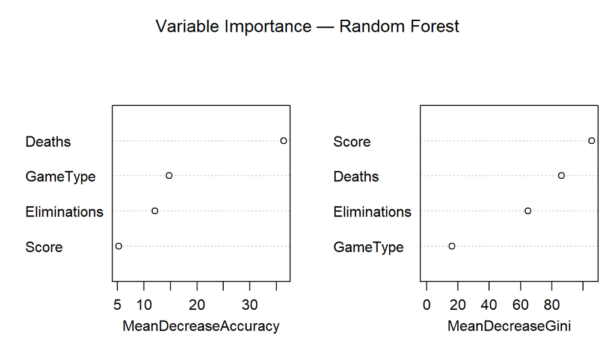

```r
varImpPlot(rf_model, main = "Variable Importance — Random Forest")
```

An interesting thing I noticed is that Deaths ranked as the most important predictor by MeanDecreaseAccuracy, which makes sense since dying frequently puts your team at a disadvantage regardless of what mode you are playing. Score actually ranked last by that same metric, even though it ranked highest in MeanDecreaseGini. The two metrics disagreeing on Score is worth noting. My hypothesis is that Score helps the trees split the data cleanly, but removing it entirely does not hurt overall accuracy as much as removing Deaths would. GameType ranked last by MeanDecreaseGini, which would suggest that win or loss comes down more to individual performance than to which game mode was being played.

### Logistic Regression

**Research Question:** “Which classification method best predicts match outcome (Win/Loss) using Score, Eliminations, Deaths, and GameType as predictors?”

We decided to choose logistic regression out of all learned classification method.

This chunk filters the dataset to include only complete matches and removes missing values in key variables. It then extracts the player’s score and opponent’s score from the Result column. The outcome variable is created by comparing these scores: if the player’s score is higher, the outcome is a win; otherwise, it is a loss.

```r
library(dplyr)
library(stringr)
library(pROC)
cod_t4 <- cod %>%
  filter(
    FullPartial == "Full",
    Result != "",
    !is.na(Score),
    !is.na(Eliminations),
    !is.na(Deaths)
  ) %>%
  mutate(
    team_score = as.numeric(str_extract(Result, "^[0-9]+")),
    opp_score  = as.numeric(str_extract(Result, "[0-9]+$")),
    Outcome = case_when(
      team_score > opp_score ~ "Win",
      team_score < opp_score ~ "Loss",
      TRUE ~ NA_character_
    )
  ) %>%
  filter(!is.na(Outcome)) %>%
  mutate(
    Outcome  = factor(Outcome, levels = c("Loss", "Win")),
    GameType = factor(GameType)
  ) %>%
  select(Outcome, Score, Eliminations, Deaths, GameType)

table(cod_t4$Outcome)
```

```
##
## Loss  Win
##  318  403
```

This chunk splits the data into a training set (80%) and a validation set (20%). The training set is used to fit the model, while the validation set is used to evaluate predictive performance on unseen data.

```r
set.seed(123)

train_ind <- sample(
  1:nrow(cod_t4),
  floor(0.8 * nrow(cod_t4))
)

Train <- cod_t4[train_ind, ]
Validation <- cod_t4[-train_ind, ]
```

This chunk fits a logistic regression model using the training data. The model estimates the probability of winning based on Score, Eliminations, Deaths, and GameType, the variables we choose as important according to game experience.

```r
log_mod <- glm(
  Outcome ~ Score + Eliminations + Deaths + GameType,
  data = Train,
  family = binomial
)

summary(log_mod)
```

```
##
## Call:
## glm(formula = Outcome ~ Score + Eliminations + Deaths + GameType,
##     family = binomial, data = Train)
##
## Coefficients:
##                          Estimate Std. Error z value Pr(>|z|)
## (Intercept)             3.490e+00  9.952e-01   3.507 0.000454 ***
## Score                   8.693e-06  1.152e-04   0.075 0.939862
## Eliminations            2.981e-02  2.183e-02   1.366 0.172089
## Deaths                 -1.702e-01  2.265e-02  -7.513 5.77e-14 ***
## GameTypeHardpoint      -9.408e-02  7.884e-01  -0.119 0.905015
## GameTypeKill Confirmed -2.023e+00  1.025e+00  -1.973 0.048510 *
## GameTypeTDM            -1.284e+00  8.063e-01  -1.592 0.111326
## ---
## Signif. codes:  0 '***' 0.001 '**' 0.01 '*' 0.05 '.' 0.1 ' ' 1
##
## (Dispersion parameter for binomial family taken to be 1)
##
##     Null deviance: 794.50  on 575  degrees of freedom
## Residual deviance: 707.81  on 569  degrees of freedom
## AIC: 721.81
##
## Number of Fisher Scoring iterations: 3
```

From the model summary:

This chunk uses the fitted logistic regression model to predict the probability of a win for each observation in the validation set. The `type = "response"` option returns predicted probabilities instead of log-odds.

```r
log_prob <- predict(
  log_mod,
  newdata = Validation,
  type = "response"
)
```

This chunk converts predicted probabilities into predicted match outcomes. I used a cutoff of 0.5: if the predicted probability of winning is at least 0.5, the prediction is “Win”; otherwise, it is “Loss”.

```r
log_pred <- ifelse(log_prob >= 0.5, "Win", "Loss")

log_pred <- factor(
  log_pred,
  levels = levels(Validation$Outcome)
)
```

### Test Set Results

This chunk evaluates the model using a confusion matrix and accuracy. The confusion matrix shows how many wins and losses were classified correctly or incorrectly. Accuracy gives the proportion of validation observations that were predicted correctly.

```r
log_conf <- table(
  Predicted = log_pred,
  Actual = Validation$Outcome
)

log_accuracy <- mean(log_pred == Validation$Outcome)

log_conf
```

```
##          Actual
## Predicted Loss Win
##      Loss   26  20
##      Win    28  71
```

```r
log_accuracy
```

```
## [1] 0.6689655
```

The logistic regression model shows moderate predictive performance. The validation accuracy is approximately 0.669, meaning that about 66.9% of match outcomes are correctly classified. This indicates that the model performs better than random guessing(50%), but there is still room for improvement.

### ROC Curve and AUC

This chunk calculates the ROC curve and AUC. AUC measures how well the model separates wins from losses across possible probability cutoffs. A larger AUC means the model is better at distinguishing wins from losses.

```r
log_roc <- roc(
  Validation$Outcome,
  log_prob,
  levels = c("Loss", "Win")
)
log_auc <- auc(log_roc)

log_auc
```

```
## Area under the curve: 0.7375
```

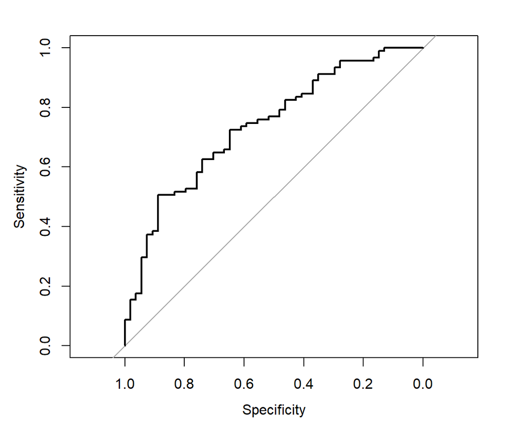

```r
plot(log_roc)
```

### Comparison

Overall, logistic regression is the better choice here, both because it outperforms the random forest on accuracy and because it is more interpretable. The coefficients tell you directly how each predictor shifts the probability of winning, which is harder to get out of a random forest. That said, neither model is particularly strong at 63-67%, which suggests that Score, Eliminations, Deaths, and GameType alone do not fully capture what separates a winning game from a losing one.